# Safety Plan Skeena 2024

Al Irvine

Al Irvine  
New Graph Environment Ltd.  
al@newgraphenvironment  
250-777-1518  
Date Original: 2024-08-09  
Date Revised: 2024-09-14

# Safety Plan - 2024-072-sern-skeena-fish-passage

The **latest version** of this pdf can be downloaded [here](https://github.com/NewGraphEnvironment/safety_plan_skeena_2024/raw/main/docs/safety_plan_sern-skeena-fish-passage.pdf). If any links in this document are broken, please ensure you are woring with the latest version (ie. download from the link).

The main goal of this fieldwork is to evaluate fish passage and establish baseline data through electrofishing techniques. We will be completing fish passage (Phase 1) and habitat confirmation (Phase 2) assessments in the Bulkley, Morice, Kispiox, and Zymoetz River watershed groups. A summary of the potential sites for fish passage assessments, habitat confirmation assessments, and electrofishing is provided in Table 5, with kml (Google Earth) and gpx (garmin) files downloadable [here](https://github.com/NewGraphEnvironment/safety_plan_skeena_2024/raw/main/docs/sites_sern-skeena-fish-passage_20240914_kml_gpx.zip).

Georeferenced pdf maps can be accessed and downloaded for each watershed using the following links: [Bulkley](https://hillcrestgeo.ca/outgoing/fishpassage/projects/bulkley/), [Kispiox](https://hillcrestgeo.ca/outgoing/fishpassage/projects/kisp/), [Zymoetz](https://hillcrestgeo.ca/outgoing/fishpassage/projects/zymo/), and [Morice](https://hillcrestgeo.ca/outgoing/fishpassage/projects/morr/).

## New Graph Employee Information

Al Irvine  
*Vehicle:* 2013 Toyota Tundra black w/flatdeck and yellow can-am quad  
*Accommodation:* Sept 15 - 25: 4036 Second Avenue B, Smithers, BC V0J 2N0  
Sept 24 - Oct 5: 3876 Second Avenue #1, Smithers, BC V0J 2N0

Lucy Schick  
*Vehicle:* 2006 Pontiac Vibe red  
*Accommodation:* 3876 Second Avenue 2, Smithers, BC V0J 2N0

## Crew Members

Table 1: Crew members details and emergency contacts

| name | email | phone | satellite | emerg_name | emerg_email | emerg_phone |
| --- | --- | --- | --- | --- | --- | --- |
| Allan Irvine | al@newgraphenvironment.com | 250-777-1518 | must be contacted by inreach first. Cannot cold call | Tara Stark | tara@newgraphenvironment.com | 250-505-9854 |
| Vern Joseph | vernon.joseph@wetsuweten.com | 250-842-8204 | truck radio equiped to call out | Brett Tripp | Brett.tripp@wetsuweten.com | 250-847-3630 ext. 2246 |
| Tiesha Pierre | pierretieasha@icloud.com | 250-877-0849 | truck radio equiped to call out | Brett Tripp | Brett.tripp@wetsuweten.com | 250-847-3630 ext. 2246 |
| Jesse Olson | jesse.olson@gitxsanbusiness.com | 778-202-0250 | – | Chaz Ware | chaz.ware@gitxsanbusiness.com | 250-877-7225 |
| Lucy Schick | lucy@newgraphenvironment.com | 604-741-2032 | 807-790-9843 | Sa Boothroyd | saboothroyd@gmail.com | 604-740-7199 |
| Jessica Doyon | jessica.doyon@gitxsanbusiness.com | 514- 778-2907 | – | Chaz Ware | chaz.ware@gitxsanbusiness.com | 250-877-7225 |

## Equipment Checklists

PLEASE NOTE THAT EQUIPMENT CHECKLISTS ARE PROVIDED FOR THE OVERALL TEAM AND NOT ALL CREWS ARE REQUIRED TO HAVE ALL EQUIPMENT. ALTHOUGH ENCOURAGED FOR ALL ENVIRONMENTAL SCIENCE TECHNICIANS AND MONITORS TO HAVE THE PERSONAL EQUIPMENT NEW GRAPH ENVIRONMENT WILL HAVE ALL EQUIPMENT NECESSARY TO COMPLETE THE WORK.

MINIMUM REQUIREMENTS FOR EACH CREW MEMBER INCLUDES GOOD QUALITY AND APPROPRIATELY FITTING LIGHT WEIGHT WADERS AND SEPERATE WADING BOOTS (RUBBER SOLED), HAT, WATER AND A FOOD.

MINIMUM REQUIREMENTS FOR FIELD TRUCKS INCLUDE A QUALITY RADIO APPROPRIATE FOR FOREST SERVICE ROADS, OFF-ROAD CAPABLE TIRES IN GOOD CONDITION, SPARE TIRE, JACK, AND TOOLS.

Table 2: Personal Equipment Checklist - SEE NOTE ABOVE FOR MINIMUM REQUIREMENTS

Equipment

GPS

water

Suncreen

food

Bugspray

gloves work

Polarized glasses

headlamp

Bear Spray

clinometer

phone/camera

field vest (surveyors)

battery pack booster for phone

note book

Hat

Extra clothes

first aid kit personal

rain gear

Waders

hand lens

Wading Boots (Rubber-soled only)

range finder

Ski poles

–

Table 3: Crew Equipment Checklist - SEE NOTE ABOVE FOR MINIMUM REQUIREMENTS

Crew Equipment Checklist

glasses safety

tape measure eslon

Hand saw

pilon x 2

Linesman Gloves x 3

Measuring board

Backroads Mapbook

Scale

Locational maps

Permits

Background Documents

Fish ID book

radio handheld

Site Cards / Field Guide

Satelite communicator

Minnow Traps

Field Safety Plan

Catfood

first aid kit level 1

Flagging

First Aid binder stocked

Laptop w/basecamp

Throw bags

GPS cable

polaski

Lazer level

shovel

Assessment cards fish passage

fire extinguisher backpack

UAV

fire extinguisher pressurized

Flow meter

hard hat

ATV

steel toed boots

bucket rigid x 2

Battery booster

bucket foldable

Compressor 12V

clove oil kit w/ instructions

Rubber boots (no-slip soles)

gloves leather

Small BT Speaker (for bears)

sharpies

Oakton Multimeter

ATV gas

Backpack Electrofisher

ATV lock

stop nets x 4

UAV battery charger

salt blocks

wader disinfectant kit

loose salt

GPS batteries

dip nets x 2

ATV helmets

tape measure hand

–

Table 4: Truck Equipment Checklist - SEE NOTE ABOVE FOR MINIMUM REQUIREMENTS

Equipment

Hand saw

truck/car jack

radio truck

Battery booster

polaski

Compressor 12V

shovel

pilon x 2

fire extinguisher backpack

Tow strap

truck tow rope

–

## Nearest Hospitals

[figure not shown]

Figure 1: Houston Health Centre - 3202 14 St, Houston, BC V0J 1Z0 - 250-845-2294

[figure not shown]

Figure 2: (Smithers) Bulkley Valley District Hospital - 3950 8 Ave, Smithers, BC V0J 2N0 - 250-847-2611

[figure not shown]

Figure 3: Wrinch Memorial Hospital - Hazelton - 2510 Hwy 62, Hazelton, BC V0J 1Y0 - 250-842-5211

## Emergency Response Plan

New Graph’s detailed emergency response procedures can be found [here](https://www.newgraphenvironment.com/hsp/plans-and-assessments.html#emergency-response-plan-erp-and-procedures). These procedures should be reviewed and an emergency response plan should be completed for each job site. Our Emergency Response Plan template can be downloaded [here](https://github.com/NewGraphEnvironment/hsp/blob/master/data/form_templates/ERP_template.pdf).

## Driving

We will be driving on forest service roads where it is essential to exercise caution and adhere strictly to all radio use protocols to ensure our safety. Proper communication on these roads helps prevent accidents by keeping everyone informed about vehicle movements and road conditions. Please review the [resource road safety](https://www.newgraphenvironment.com/hsp/safe-work-procedures-and-practices.html#resource-road-safety) and [radio use](https://www.newgraphenvironment.com/hsp/safe-work-procedures-and-practices.html#radio-use) sections of our Health and Safety plan so that everyone stays safe.

## Field Plan

The primary objective of the fieldwork is to assess fish passage, habitat conditions and establish baseline monitoring, using electrofishing techniques. We will be completing fish passage (Phase 1) and habitat confirmation (Phase 2) assessments in the Bulkley, Morice, Kispiox, and Zymoetz River watershed groups. Fieldwork methods will produce reports such as the [Skeena Watershed Fish Passage Restoration Planning 2023](https://www.newgraphenvironment.com/fish_passage_skeena_2023_reporting/). Additional reports can be found [here](https://www.newgraphenvironment.com/fish_passage_skeena_2023_reporting/executive-summary.html).

Although currently incomplete and in rough draft format - fieldwork procedures can be found in our [Fish Passage Guidebook](https://www.newgraphenvironment.com/fish_passage_guidebook/). We generally follow procedures in:

- [fish passage assessments](https://www2.gov.bc.ca/assets/gov/environment/natural-resource-stewardship/land-based-investment/forests-for-tomorrow/field-assessment-for-determining-fish-passage-status-of-cbs.pdf) (BC Ministry of Environment 2011)
- [habitat confirmations](https://www2.gov.bc.ca/assets/gov/environment/natural-resource-stewardship/land-based-investment/forests-for-tomorrow/checklist-for-fish-habitat-confirmation-201112.pdf) (Fish Passage Technical Working Group 2011).

Presence/absence of fish, species composition/density and distribution limits can be useful for prioritizing which crossings are a best fit for fish passage restoration and help inform follow up monitoring so electrofishing and minnowtrapping may be conducted. Standard Fish and Fish Habitat Inventory Standard Field Form [Site Cards](https://www2.gov.bc.ca/gov/content/environment/natural-resource-stewardship/laws-policies-standards-guidance/inventory-standards/aquatic-ecosystems) are used to gather habitat data, and the Field Guide to these Site Cards can be found [here](https://www2.gov.bc.ca/assets/gov/environment/natural-resource-stewardship/nr-laws-policy/risc/sitecard20.pdf).

We have PIT tagging equipment and could consider [tagging](https://www.youtube.com/watch?v=9CKZ9yaS5o8) fish captured at electrofishing sites to help us better understand population sizes and fish movement upstream and downstream of sites over the years.

We use digital field form using a product called [Mergin Maps](https://merginmaps.com/?gclid=Cj0KCQjwxb2XBhDBARIsAOjDZ34oq-iMid3vRrgK1ZAkJ_yiz4aWY-LLF90PHiXzELbZIrxooV9vWKYaAgl2EALw_wcB) which syncs with QGIS. Please see our [Fish Passage Guidebook](https://www.newgraphenvironment.com/fish_passage_guidebook/data-collection-and-field-navigation.html#mergin-maps) for instructions on how to set up Mergin Maps and use our digital field forms. Please send me your usernames and we can begin to share projects/forms.

A guide to freshwater fish id such as McPhail and Carveth (1993) can be useful and can be downloaded [here](https://a100.gov.bc.ca/pub/acat/documents/r13659/486FieldKeytoFreshwaterFishes1993Part1of2_1210014849226_8e248a8d30d97e6c45ef54a340babd2ffb57b14a3b16.pdf).

### Check In Procedures

Call, text or inReach Tara Stark (2505059854) each morning to share the plan for the day (i.e. name of roads and sites). Check in time is before 7 pm each evening although we regularly check in throughout the day (ex. at arrival to site, 1pm and 4pm) on the inReach or by text and report position/provide updates.

#### Procedures for Failed Check-In - for Check in person

Procedures are summarized in Figure 4. If a phone call or inReach check-in is not received by 7 PM, first send a text to the inReach units, then call or text the cell phones of field crew members. If no response, please call accommodations then personal emergency contacts to see if they have heard anything. Wait 1 hour and text inReach, text or call cell phones and personal emergency contacts and accommodations again. Repeat after 2 hours (9 pm) - if no response then notify the RCMP of a missing persons in the field.

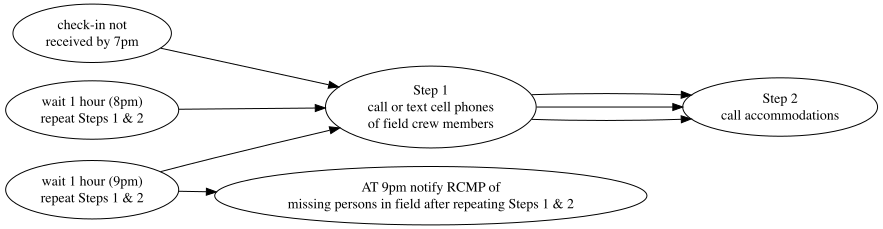

Figure 4: Procedures for failed check-in

[figure not shown]

Figure 5: Map of potential sampling areas.

Table 5: Potential Phase 1 assessment, Phase 2 assessment, and Electrofishing Locations

| id | stream_name | utm_zone | utm_easting | utm_northing | watershed_group_code | pscis_assessment_comment |
| --- | --- | --- | --- | --- | --- | --- |
| 8525 | Copper | 9 | 581004 | 6074666 | ZYMO | No action warranted at this crossing, although there is potential for embedding existing pipe to ensure fish passage. High habitat value upstream of crossing for 100m, then stream becomes grassy wetla… |
| 8530 | Sandstone Creek | 9 | 582713 | 6073870 | ZYMO | Channel is steeper downstream of culvert. Very deep fill with a small outlet drop. 10:59 |
| 8547 | Copper | 9 | 589980 | 6072661 | ZYMO | Recommend fish survey. If positive then remove culvert and replace with open bottom structure. |
| 58067 | Tributary to Gramophone Creek | 9 | 609726 | 6092894 | BULK | Replace with OBS |
| 58242 | Kathlyn Creek | 9 | 616947 | 6073197 | BULK | If culvert is proven to be a barrier, install OBS |
| 123377 | Thompson Creek | 9 | 641633 | 6049398 | BULK | Debris is partially blocking one of the two pipes. Historic washouts on road at this site. Landowner reports stream diverted downstream &gt;50 years ago and crosses farmers field in ditched channel. 1… |
| 123393 | Lemieux creek | 9 | 638516 | 6054722 | BULK | Very deep outlet pool. Wetland downstream and beaver activity upstream. Almost fully backwatered, very little flow through the culvert. 13:32 |
| 123426 | Robin Creek | 9 | 636935 | 6056693 | BULK | Embedded culvert with high flow. 14:37 |
| 124422 | Tributary to Waterfall Creek | 9 | 589500 | 6123161 | BULK | 2 pipes. Both have water, left bank one is flowing. Assessment comments indicate right bank pipe is backwatered 100% but changed to 25% based on photos and past PSCIS data and photos which also indica… |
| 124500 | Helps Creek | 9 | 627541 | 6058702 | BULK | Wetland type habitat upstream with stream channel containing abundant gravels downstream. |
| 195934 | Stock Creek | 9 | 645134 | 6034600 | BULK | Currently 2 CVs, no access at low water |
| 197379 | Tributary to Owen Creek | 9 | 640960 | 6005930 | MORR | Two thirds of culvert on upstream side has baffles. Fish sampling and PIT tagging conducted. Design underway by MoF. 13:18 |
| 197668 | Coffin Creek | 9 | 634342 | 6054605 | BULK | CN crossing has had Newbury riffles constructed to decrease the size of the outlet drop but drop still present. Abundant gravels suitable for spawning chinook and coho present. Some deep pools availab… |
| 198217 | Tributary to Skeena River | 9 | 582875 | 6130541 | KISP | Francis (chief) indicated this is historic coho harvest site for Glen Vowell community and historic coho spawning stream. 2 1.25m culverts side by side. Trash rack has been removed from inlet. Inlet h… |
| 198916 | Gershwin Creek | 9 | 580429 | 6115770 | KISP | Very high value habitat upstream with pockets of gravel throughout. Adult cutthroat or rainbow observed just downstream of Highway 16 crossing upstream of here. Structure is dated 1923. Water flows wi… |

# References

BC Ministry of Environment. 2011. *Field Assessment for Determining Fish Passage Status of Closed Bottom Structures*. Manual. Victoria, British Columbia: BC Ministry of Environment. https://www2.gov.bc.ca/assets/gov/environment/natural-resource-stewardship/land-based-investment/forests-for-tomorrow/field-assessment-for-determining-fish-passage-status-of-cbs.pdf.

Fish Passage Technical Working Group. 2011. “A Checklist for Fish Habitat Confirmation Prior to the Rehabilitation Fo a Stream Crossing.” https://www2.gov.bc.ca/assets/gov/environment/natural-resource-stewardship/land-based-investment/forests-for-tomorrow/checklist-for-fish-habitat-confirmation-201112.pdf.

McPhail, J. D., and R Carveth. 1993. “Field Key to the Freshwater Fishes of British Columbia.” https://www2.gov.bc.ca/assets/gov/environment/natural-resource-stewardship/nr-laws-policy/risc/field_key_to_freshwater_fishes_of_bc_field_size_water_resistant_version.pdf.